# Practical Machine Learning Assignment

Pankaj Ojha

February 8, 2018

## BACKGROUND

Using devices such as Jawbone Up, Nike FuelBand, and Fitbit it is now possible to collect a large amount of data about personal activity relatively inexpensively. These type of devices are part of the quantified self movement - a group of enthusiasts who take measurements about themselves regularly to improve their health, to find patterns in their behavior, or because they are tech geeks. One thing that people regularly do is quantify how much of a particular activity they do, but they rarely quantify how well they do it. In this project, your goal will be to use data from accelerometers on the belt, forearm, arm, and dumbell of 6 participants. They were asked to perform barbell lifts correctly and incorrectly in 5 different ways. More information is available from the website here: http://groupware.les.inf.puc-rio.br/har (see the section on the Weight Lifting Exercise Dataset).

## Data Files

The training data for this project are available here: https://d396qusza40orc.cloudfront.net/predmachlearn/pml-training.csv

The test data are available here: https://d396qusza40orc.cloudfront.net/predmachlearn/pml-testing.csv

The data for this project come from this source: http://groupware.les.inf.puc-rio.br/har.

If you use the document you create for this class for any purpose please cite them as they have been very generous in allowing their data to be used for this kind of assignment.

## Purpose

The goal of this project is to predict the manner in which participant did the exercise. The “classe” variable in the training set defined the manner by which participant perform the exercise. The various variables can be used predict “classe”. The report describe how the models are built, how the cross validation is done, what is the expected sample error, and why the particular model is used. The prediction model will be used to predict 20 different test cases.

```r
library(e1071)
library(dplyr)
library(ggplot2)
library(tidyverse)
library(caret)
library(kernlab)
library(rattle)
library(gbm)
library(forecast)
library(rpart.plot)
library(randomForest)
library(corrplot)
```

## Getting the data

Fetching the data directly from website is time consuming, thus I have downloaded the data locally in my hard disk to perform the various model. Also, I have given the approach to directly access the data from site.

```r
traindat = read.csv("./pml-training.csv")
testdat = read.csv("./pml-testing.csv")

# UrlTrain <- "http://d396qusza40orc.cloudfront.net/predmachlearn/pml-training.csv"
# UrlTest  <- "http://d396qusza40orc.cloudfront.net/predmachlearn/pml-testing.csv"
#
# # download the datasets
# traindat <- read.csv(url(UrlTrain))
# testdat  <- read.csv(url(UrlTest))
```

Set the seed for Reproducibility

```r
set.seed(12345)
```

Create a partition with the training dataset into TrainSet and TestSet

```r
# create a partition with the training dataset
inTrain  <- createDataPartition(traindat$classe, p=0.7, list=FALSE)
TrainSet <- traindat[inTrain, ]
TestSet  <- traindat[-inTrain, ]

dim(TrainSet); dim(TestSet)
```

```
## [1] 13737   160
```

```
## [1] 5885  160
```

## Cleansing of Data

First, find the near Zero variables columns

```r
# Find the near Zero variaoble columns
NZV <- nearZeroVar(TrainSet,saveMetrics=TRUE)
TrainSet <- TrainSet[ ,NZV$nzv==FALSE]
TestSet  <- TestSet[ ,NZV$nzv==FALSE]
dim(TrainSet); dim(TestSet)
```

```
## [1] 13737   106
```

```
## [1] 5885  106
```

Remove the variables that are mostly NA

```r
VarNA    <- sapply(TrainSet, function(x) mean(is.na(x))) > 0.95
TrainSet <- TrainSet[, VarNA==FALSE]
TestSet  <-  TestSet[, VarNA==FALSE]
dim(TrainSet); dim(TestSet)
```

```
## [1] 13737    59
```

```
## [1] 5885   59
```

Remove identification only variables (columns 1 to 5)

```r
TrainSet <- TrainSet[, -(1:5)]
TestSet  <- TestSet[, -(1:5)]
dim(TrainSet); dim(TestSet)
```

```
## [1] 13737    54
```

```
## [1] 5885   54
```

## Corelation Analysis

Find the corelated variables

```r
CorM <- abs(cor(TrainSet[,-54]))
diag(CorM) <- 0
which(CorM > 0.8,arr.ind=T)
```

[output not shown]

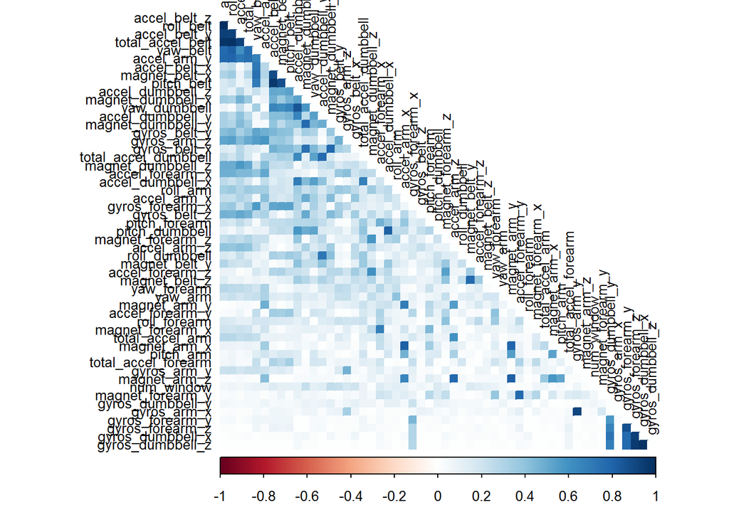

```r
corrplot(CorM, order = "FPC", method = "color", type = "lower",
         tl.cex = 0.8, tl.col = rgb(0, 0, 0))
```

## 1. Random Forest

Build the first model with Random forest

```r
modelFitRF <- train( classe ~.,method="rf",
               data=TrainSet,
               trControl = trainControl(method="cv"),number=3)


modelFitRF$finalModel
```

```
##
## Call:
##  randomForest(x = x, y = y, mtry = param$mtry, number = 3)
##                Type of random forest: classification
##                      Number of trees: 500
## No. of variables tried at each split: 27
##
##         OOB estimate of  error rate: 0.17%
## Confusion matrix:
##      A    B    C    D    E  class.error
## A 3904    1    0    0    1 0.0005120328
## B    6 2650    1    1    0 0.0030097818
## C    0    5 2391    0    0 0.0020868114
## D    0    0    6 2246    0 0.0026642984
## E    0    0    0    3 2522 0.0011881188
```

```r
predictRF <- predict(modelFitRF, newdata = TestSet)
confMatRF <- confusionMatrix(predictRF,TestSet$classe)
```

## 2. Decision Tree

Build the second model with Decision Tree

```r
modelFitRPART <- train(classe ~ .,method="rpart",data=TrainSet)
modelFitRPART$finalModel
```

```
## n= 13737
##
## node), split, n, loss, yval, (yprob)
##       * denotes terminal node
##
##  1) root 13737 9831 A (0.28 0.19 0.17 0.16 0.18)
##    2) roll_belt< 129.5 12512 8649 A (0.31 0.21 0.19 0.18 0.11)
##      4) pitch_forearm< -33.95 1093   10 A (0.99 0.0091 0 0 0) *
##      5) pitch_forearm>=-33.95 11419 8639 A (0.24 0.23 0.21 0.2 0.12)
##       10) num_window>=45.5 10901 8121 A (0.26 0.24 0.22 0.2 0.085)
##         20) magnet_dumbbell_y< 439.5 9307 6587 A (0.29 0.19 0.25 0.19 0.082)
##           40) roll_forearm< 123.5 5861 3418 A (0.42 0.19 0.19 0.16 0.042) *
##           41) roll_forearm>=123.5 3446 2249 C (0.08 0.19 0.35 0.23 0.15) *
##         21) magnet_dumbbell_y>=439.5 1594  688 B (0.038 0.57 0.05 0.24 0.1) *
##       11) num_window< 45.5 518  106 E (0 0 0 0.2 0.8) *
##    3) roll_belt>=129.5 1225   43 E (0.035 0 0 0 0.96) *
```

```r
predictRPART <- predict(modelFitRPART, newdata = TestSet)
confMatRPART <- confusionMatrix(predictRPART,TestSet$classe)
```

Plot the Decision Tree

[figure not shown]

```r
fancyRpartPlot(modelFitRPART$finalModel)
```

## 3. Generalized Boosted Model

```r
modelFitGBM <- train(classe ~.,data=TrainSet, method="gbm")
modelFitGBM$finalModel
predictGBM <- predict(modelFitGBM, newdata = TestSet)
confMatGBM <- confusionMatrix(predictGBM,TestSet$classe)
```

[output not shown]

## 4. Combined Model

```r
predComDF <- data.frame(predictRF,predictRPART,predictGBM,classeC = TestSet$classe )
combineFitRF <- train(classeC ~., data=predComDF, method = "rf")
combinePredRF <- predict(combineFitRF,predComDF)
confMatCOM <- confusionMatrix(combinePredRF,TestSet$classe)
```

Accuracy of various Algorithim

```r
#Random Forest
confusionMatrix(predictRF,TestSet$classe)$overall[1]
```

```
##  Accuracy
## 0.9962617
```

```r
#Decision Tree
confusionMatrix(predictRPART,TestSet$classe)$overall[1]
```

```
##  Accuracy
## 0.5237043
```

```r
#Generalized Boosted Model
confusionMatrix(predictGBM,TestSet$classe)$overall[1]
```

```
##  Accuracy
## 0.9835174
```

```r
#Combined Model
confusionMatrix(combinePredRF,TestSet$classe)$overall[1]
```

```
##  Accuracy
## 0.9972812
```

The expected out-of-sample error is

```r
SampleError <- 1 - confusionMatrix(predictRF,TestSet$classe)$overall[1]
SampleError
```

```
##    Accuracy
## 0.003738318
```

Prepare the test data by removing Near zero Value, NA and identification variables

```r
NZV <- nearZeroVar(testdat,saveMetrics=TRUE)
testdat <- testdat[ ,NZV$nzv==FALSE]
dim(testdat);
```

```
## [1] 20 59
```

```r
# remove variables that are mostly NA
VarNA    <- sapply(testdat, function(x) mean(is.na(x))) > 0.95
testdat <- testdat[, VarNA==FALSE]
dim(testdat)
```

```
## [1] 20 59
```

```r
# remove identification only variables (columns 1 to 5)
testdat <- testdat[, -(1:5)]
dim(testdat)
```

```
## [1] 20 54
```

Predict the out come of test data set.

```r
testPred <- predict(modelFitRF,newdata=testdat)
testPred
```

```
##  [1] B A B A A E D B A A B C B A E E A B B B
## Levels: A B C D E
```